# poLCA_R

## Polytomous variable Latent Class Analysis

(多分岐可変潜在クラス分析)

## インストールログ

- 以下ではエラーとなった。

```
#潜在クラス分析テスト　←2017/7/3
install.packages("poLCA", dependencies = TRUE)
library(poLCA)
library(xlsx)　　#ライブラリーの読み込み
----
Error in contrib.url(repos, "source"): trying to use CRAN without setting a mirror
Traceback:

1. install.packages("poLCA", dependencies = TRUE)
2. contrib.url(repos, "source")
3. stop("trying to use CRAN without setting a mirror")
```

- そこで、 [How do I set a CRAN mirrror to install an R package in Jupyter? · Issue #234 · IRkernel/IRkernel](https://github.com/IRkernel/IRkernel/issues/234)  
  を参照して、

```
country.code <- 'ja'  # use yours
url.pattern <- 'http://'  # use http if you want
repo.data.frame <- subset(getCRANmirrors(), CountryCode == country.code & grepl(url.pattern, URL))
options(repos = repo.data.frame$URL)
```

```
をやってみたが、うまくいかなかった。
```

- そこで、 [CRAN国内ミラーの使い方 - RjpWiki](http://www.okadajp.org/RWiki/?CRAN%E5%9B%BD%E5%86%85%E3%83%9F%E3%83%A9%E3%83%BC%E3%81%AE%E4%BD%BF%E3%81%84%E6%96%B9)  
  をみて

```
options(repos="http://cran.md.tsukuba.ac.jp")
install.packages("poLCA", dependencies = TRUE)
```

```
をやってみたが、
```

```
Warning message:
"unable to access index for repository http://cran.md.tsukuba.ac.jp/src/contrib:
   URL 'http://cran.md.tsukuba.ac.jp/src/contrib/PACKAGES' を開けません "Warning message:
"package 'poLCA' is not available (for R version 3.3.2)"Warning message:
"unable to access index for repository http://cran.md.tsukuba.ac.jp/bin/windows/contrib/3.3:
   URL 'http://cran.md.tsukuba.ac.jp/bin/windows/contrib/3.3/PACKAGES' を開けません "
```

```
となった。
```

- そこで、ローカルでRを立ち上げて、

```
> install.packages("poLCA", dependencies = TRUE)
 --- このセッションで使うために、CRAN のミラーサイトを選んでください ---
 依存対象 (dependency) ‘scatterplot3d’ もインストールします

 URL 'https://cran.ism.ac.jp/bin/windows/contrib/3.3/scatterplot3d_0.3-40.zip' を試しています
Content type 'application/zip' length 309031 bytes (301 KB)
downloaded 301 KB

 URL 'https://cran.ism.ac.jp/bin/windows/contrib/3.3/poLCA_1.4.1.zip' を試しています
Content type 'application/zip' length 420567 bytes (410 KB)
downloaded 410 KB

 パッケージ ‘scatterplot3d’ は無事に展開され、MD5 サムもチェックされました
 パッケージ ‘poLCA’ は無事に展開され、MD5 サムもチェックされました

 ダウンロードされたパッケージは、以下にあります
        C:\Users\tateno\AppData\Local\Temp\RtmpQ7ldzH\downloaded_packages
>
```

```
となった。
```

- そこで

```
options(repos="https://cran.ism.ac.jp")
install.packages("poLCA", dependencies = TRUE)
```

```
とすると、
```

```
also installing the dependency 'scatterplot3d'

package 'scatterplot3d' successfully unpacked and MD5 sums checked
package 'poLCA' successfully unpacked and MD5 sums checked

The downloaded binary packages are in
    C:\Users\tateno\AppData\Local\Temp\RtmpiMMKKB\downloaded_packages
```

```
となってうまくいった。
```

- 残りのパッケージもインストールする。

```
install.packages("xlsx", dependencies = TRUE)
----
also installing the dependencies 'rJava', 'xlsxjars'

package 'rJava' successfully unpacked and MD5 sums checked
package 'xlsxjars' successfully unpacked and MD5 sums checked
package 'xlsx' successfully unpacked and MD5 sums checked

The downloaded binary packages are in
    C:\Users\tateno\AppData\Local\Temp\RtmpET0rSG\downloaded_packages
```

```
#install.packages("openxlsx", repos="https://cran.ism.ac.jp")
#library(openxlsx)　　#ライブラリーの読み込み
```

## 1. 使用するパッケージをインストールする。

```r
options(repos="https://cran.ism.ac.jp")
install.packages("poLCA", dependencies = TRUE)
install.packages("openxlsx", dependencies = TRUE)
```

```r
#潜在クラス分析テスト　←2017/7/3
library(poLCA)
#library(xlsx)　　#ライブラリーの読み込み
library(openxlsx)
```

```r
# ヘルプで確認
?read.xlsx
```

```r
# openxlsxの場合
m1<-read.xlsx("data/foundation_0_htext_fa3_d3w20n100e200f1_E.xlsx", sheet = 1)

# xlsxの場合
#m1<-read.xlsx("data/foundation_0_htext_fa3_d3w20n100e200f1_E.xlsx",encoding="UTF-8", sheetIndex=1)
```

```r
head(m1)
```

| X1 | A1 | A2 | A3 | A4 | A5 | A6 | A7 | A8 | A9 | ... | A91 | A92 | A93 | A94 | A95 | A96 | A97 | A98 | A99 | A100 |
| --- | --- | --- | --- | --- | --- | --- | --- | --- | --- | --- | --- | --- | --- | --- | --- | --- | --- | --- | --- | --- |
| 0 | 1 | 1 | 1 | 1 | 1 | 1 | 1 | 1 | 1 | ... | 1 | 1 | 1 | 1 | 1 | 1 | 1 | 1 | 1 | 1 |
| 1 | 2 | 1 | 1 | 1 | 1 | 2 | 1 | 1 | 1 | ... | 1 | 1 | 1 | 1 | 1 | 1 | 1 | 1 | 1 | 1 |
| 2 | 1 | 1 | 1 | 1 | 1 | 1 | 1 | 1 | 1 | ... | 1 | 1 | 1 | 1 | 1 | 1 | 1 | 1 | 1 | 1 |
| 3 | 1 | 1 | 1 | 1 | 1 | 1 | 1 | 1 | 1 | ... | 1 | 1 | 1 | 1 | 1 | 1 | 1 | 1 | 1 | 1 |
| 4 | 1 | 1 | 1 | 1 | 1 | 1 | 1 | 1 | 1 | ... | 1 | 1 | 1 | 1 | 1 | 1 | 1 | 1 | 1 | 1 |
| 5 | 1 | 1 | 1 | 1 | 1 | 1 | 1 | 1 | 1 | ... | 1 | 1 | 1 | 1 | 1 | 1 | 1 | 1 | 1 | 1 |

## 2. 列名のリストを作成し、fを形成する。

[r - The difference between concatenating character strings with paste() vs. cat()? - Stack Overflow](https://stackoverflow.com/questions/12775085/the-difference-between-concatenating-character-strings-with-paste-vs-cat)  
[eval 関数の使い方](https://stats.biopapyrus.jp/r/devel/eval.html)

```r
source('progs/poLCA.R')

colnames_chars <- set_colnames_chars(m1)
#colnames_chars
eval(parse(text = colnames_chars))
f
```

```
cbind(A1, A2, A3, A4, A5, A6, A7, A8, A9, A10, A11, A12, A13,
    A14, A15, A16, A17, A18, A19, A20, A21, A22, A23, A24, A25,
    A26, A27, A28, A29, A30, A31, A32, A33, A34, A35, A36, A37,
    A38, A39, A40, A41, A42, A43, A44, A45, A46, A47, A48, A49,
    A50, A51, A52, A53, A54, A55, A56, A57, A58, A59, A60, A61,
    A62, A63, A64, A65, A66, A67, A68, A69, A70, A71, A72, A73,
    A74, A75, A76, A77, A78, A79, A80, A81, A82, A83, A84, A85,
    A86, A87, A88, A89, A90, A91, A92, A93, A94, A95, A96, A97,
    A98, A99, A100) ~ 1
```

[R出力の記録 - RjpWiki](http://www.okadajp.org/RWiki/?R%E5%87%BA%E5%8A%9B%E3%81%AE%E8%A8%98%E9%8C%B2)

```r
# help
?poLCA
```

[write(リスト名, "出力するファイルのパス", append = T, ncolumns = 一行の要素の数)](http://cse.naro.affrc.go.jp/takezawa/r-tips/r/45.html)

## 4. poLCAを実行する。

```
Conditional item response (column) probabilities,
 by outcome variable, for each class (row)

$A1
           Pr(1)  Pr(2)
class 1:  0.9352 0.0648
class 2:  0.3483 0.6517
class 3:  0.8687 0.1313
class 4:  0.8677 0.1323

$A2
           Pr(1)  Pr(2)
class 1:  1.0000 0.0000
class 2:  0.9767 0.0233
class 3:  0.6014 0.3986
class 4:  0.9681 0.0319

$A3
           Pr(1)  Pr(2)
class 1:  0.9933 0.0067
class 2:  0.9813 0.0187
class 3:  0.9928 0.0072
class 4:  0.0856 0.9144

$A4
           Pr(1)  Pr(2)
class 1:  0.9790 0.0210
class 2:  0.8265 0.1735
class 3:  0.9590 0.0410
class 4:  0.9457 0.0543

$A5
           Pr(1)  Pr(2)
class 1:  1.0000 0.0000
class 2:  0.8195 0.1805
class 3:  0.9928 0.0072
class 4:  0.9662 0.0338

$A6
           Pr(1)  Pr(2)
```

[output cut: 668 more lines]

```

=========================================================
Fit for 4 latent classes:
=========================================================
number of observations: 10859
number of estimated parameters: 403
residual degrees of freedom: 10456
maximum log-likelihood: -66742.38

AIC(4): 134290.8
BIC(4): 137229.7
G^2(4): 22009.71 (Likelihood ratio/deviance statistic)
X^2(4): 5.985096e+14 (Chi-square goodness of fit)

ALERT: iterations finished, MAXIMUM LIKELIHOOD NOT FOUND
```

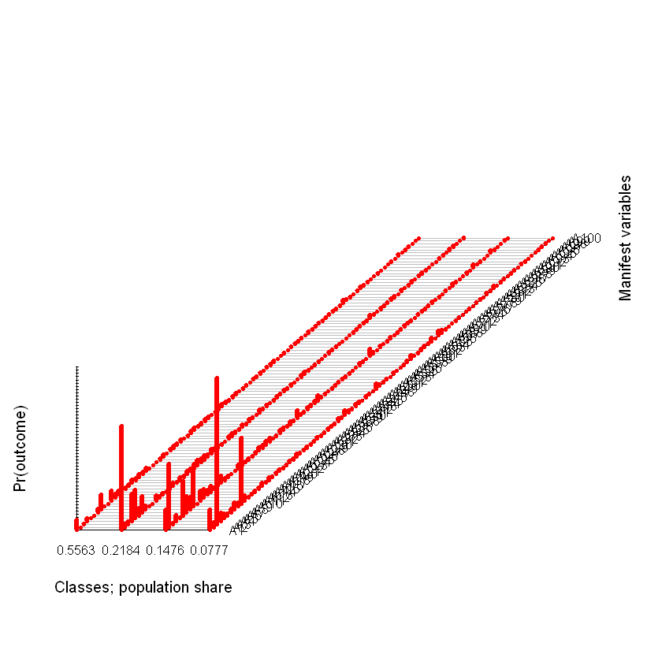

```r
M2 <- poLCA(f,m1,nclass=4, graph=TRUE) #nclassでクラス数を指定
```

## 5. 上記4と同じ処理を実行し、実行結果をファイルに書き出す。

```r
t=capture.output(M2 <- poLCA(f,m1,nclass=4)) #nclassでクラス数を指定
write(t, file="data/M2.txt")
```

[What is the meaning of the dollar sign "$" in R function()? - Stack Overflow](https://stackoverflow.com/questions/42560090/what-is-the-meaning-of-the-dollar-sign-in-r-function)

```r
getwd()
```

'G:/SVN/HRDataScientistWG/poLCA/ipynb/poLCA_set'

## 6. クラス数を1～5まで変えて、最適なクラス数を見つける

```r
source('progs/poLCA.R')

#適正クラス数の調査＆グラフ化（ネットより入手）
minc <- 1 #最小クラス数
maxc <- 5 #最大クラス数
pol.out <- matrix(0, maxc, 5)
maxiter <- 100000
# 計算にかなり時間がかかるので注意
pol.out <- calc_pol("data/M3.txt", minc, maxc, maxiter, pol.out)
pol.out
```

[output not shown]

```r
pol.out[,1:3]
```

|  | AIC | BIC | CAIC |
| --- | --- | --- | --- |
| 1 | 139099.3 | 139828.5 | 139928.5 |
| 2 | 139245.9 | 140711.8 | 140912.8 |
| 3 | 137868.3 | 140070.8 | 140372.8 |
| 4 | 134837.5 | 137776.4 | 138179.4 |
| 5 | 133723.5 | 137399.1 | 137903.1 |

```r
#write(pol.out, file="data/polout.txt")
write.table(pol.out[,1:3], "data/polout.txt")
```

**png:** 2

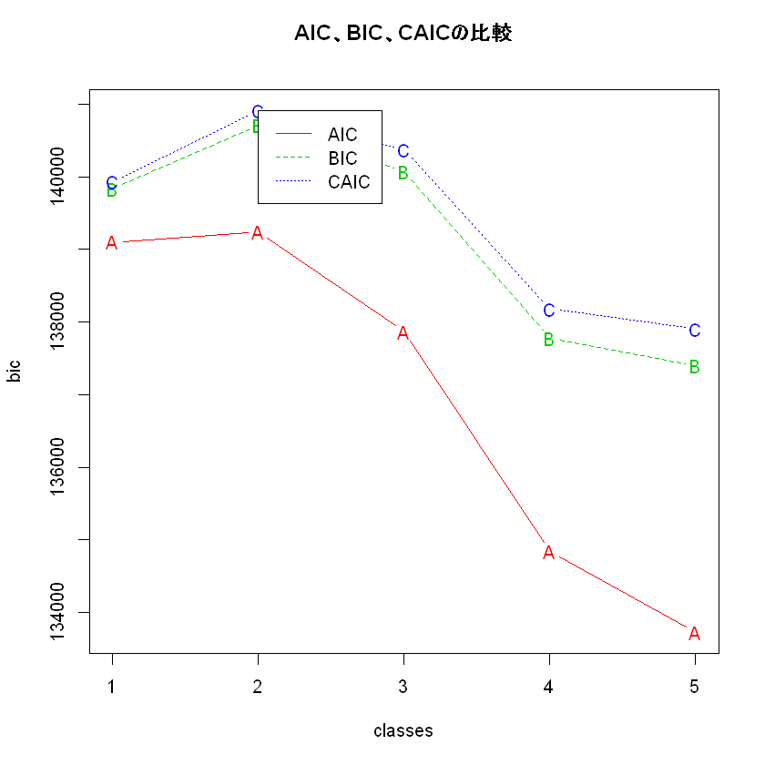

```r
source('progs/poLCA.R')
draw_AIC_BIC_CAIC(minc, maxc)
```

## ここでpoLCA_Pyにもどる

poLCA_Py

# 参考

- Estimated class population shares
  - [RのpoLCAパッケージで潜在クラス分析を行う - 井出草平の研究ノート](http://ides.hatenablog.com/entry/2017/06/21/145338)
- polca statistics
  - [Example for a latent class analysis with the poLCA-package in R - ahoi data](http://statistics.ohlsen-web.de/latent-class-analysis-polca/)
- Conditional item response (column) probabilities
  - lca2013.pdf
- [R のグラフはベクタ（ベクトル）画像で出力すべきたった１つの理由](http://rstudio-pubs-static.s3.amazonaws.com/3329_37cff1e3150d4002bb3dee7dc88e0bf3.html)